# Machine Learning

Steve de Peijper

Sunday, March 6th, 2016

# Introduction

Using devices such as Jawbone Up, Nike FuelBand, and Fitbit it is now possible to collect a large amount of data about personal activity relatively inexpensively. These type of devices are part of the quantified self movement – a group of enthusiasts who take measurements about themselves regularly to improve their health, to find patterns in their behavior, or because they are tech geeks. One thing that people regularly do is quantify how much of a particular activity they do, but they rarely quantify how well they do it. In this project we use data from accelerometers on the belt, forearm, arm, and dumbell of 6 participants. They were asked to perform barbell lifts correctly and incorrectly in 5 different ways. More information is available from the website here: http://groupware.les.inf.puc-rio.br/har (see the section on the Weight Lifting Exercise Dataset).

### Goal and approach

We will try to prodict the correct classification. We will first try a simple model that is very descriptive; a traditional tree. Later on we will try a randon forest to see whether this is more accurate.

# Data

We will load the data, transform it and split in training and testset.

### Load data

We will load the prepared data.

```r
train = read.csv("C:/TFS/Additional/R/Machine Learning/Project/pml-training.csv")
validate = read.csv("C:/TFS/Additional/R/Machine Learning/Project/pml-testing.csv")
```

### Data wrangling

Change the datatype.

```r
train$classe = as.factor(train$classe)
```

Remove incomplete columns and focus on the columns of interest.

```r
incompleteColumns <- sapply(train, function (x) any(is.na(x) | x == ""))
focusAreas = grepl("belt|_arm|dumbbell|forearm", colnames(train))
finalColumns = !incompleteColumns & focusAreas
finalColNames = c(colnames(train[,finalColumns]),"classe")
```

### Cross validation

Split in training and testingset, 75% training, 25% test. This will allow us to estimate the out of sample error.

```r
inTrain = createDataPartition(train$classe, p = 3/4)[[1]]
training = train[ inTrain,finalColNames]
testing = train[-inTrain,finalColNames]
```

# Model building process

We will try to create a model that is easily interpretatble. For this reason we fit a regular tree. Later on we will try a more advanced method (random forest).

### Parameter tuning

Before build a tree we set the parameters. Cross validation (3 folds) was used for parameter tuning. This performs wel and remains accurate enough.

```r
fitControl <- trainControl(
  method = "cv",
  number = 3,
  allowParallel=TRUE  )
```

## Fitting one tree

We fit a simple model.

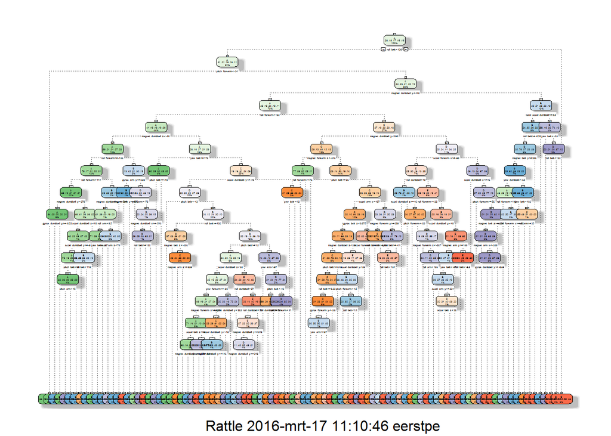

```r
modfit = train(classe ~ ., data=training, method="rpart" , trControl=fitControl, tuneLength=50)
fancyRpartPlot(modfit$finalModel)
```

View the number of predictions, the accuracy on the training- and testset:

```r
d = data.frame(predict(modfit, training))
colnames(d) = "prediction"
length(d$prediction)
```

```
## [1] 14718
```

```r
confusionMatrix(predict(modfit, training),training$classe)$overall['Accuracy']
```

```
##  Accuracy
## 0.9181275
```

```r
confusionMatrix(predict(modfit, testing),testing$classe)$overall['Accuracy']
```

```
##  Accuracy
## 0.9002855
```

We built one tree that is human readible, althoug is it very extensive. The accuracy is very high, not only on the training set, but also on the testset, indicating its not overfitting.

## Multiple trees

What would happen when we create multiple tries (a lot) with few predictors. This could improve accuracy.

We set the tuning parameters to use only a few predictors per tree:

```r
mtryGrid <- expand.grid(mtry = c(8,10, 11))
```

### Fitting and results

The random forest treefit:

```r
TreeFit <- train(classe ~ ., data = training[, finalColNames],
                 method = "rf", ntree=300, trControl=fitControl, tuneGrid =mtryGrid)
```

The following number of variables have been chosen at each split:

```r
TreeFit$finalModel$mtry
```

```
## [1] 8
```

The accuracy of the model on the trainingset:

```r
confusionMatrix(predict(TreeFit, training),training$classe)$overall['Accuracy']
```

```
## Accuracy
##        1
```

The accuracy of the model on the testset:

```r
confusionMatrix(predict(TreeFit, testing),testing$classe)$overall['Accuracy']
```

```
##  Accuracy
## 0.9967374
```

Error rate:

```r
1 - confusionMatrix(predict(TreeFit, testing),testing$classe)$overall['Accuracy']
```

```
##    Accuracy
## 0.003262643
```

### Conclusion

A single tree yielded good results. The randon forest yielded even better results. For understanding the single tree is preferrable because it can be explained more easily.